# 140.651 - Lab 15

### HW6 Problem 6

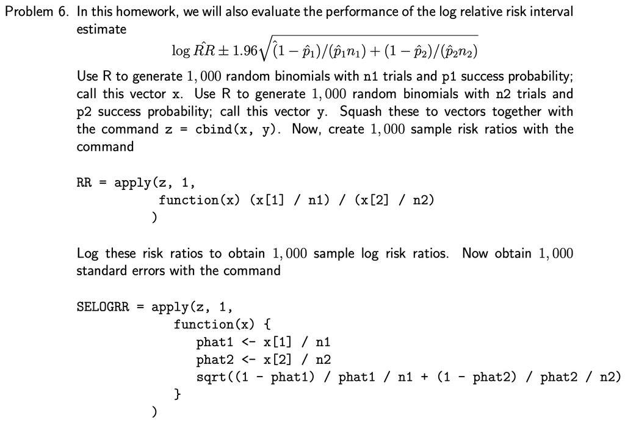

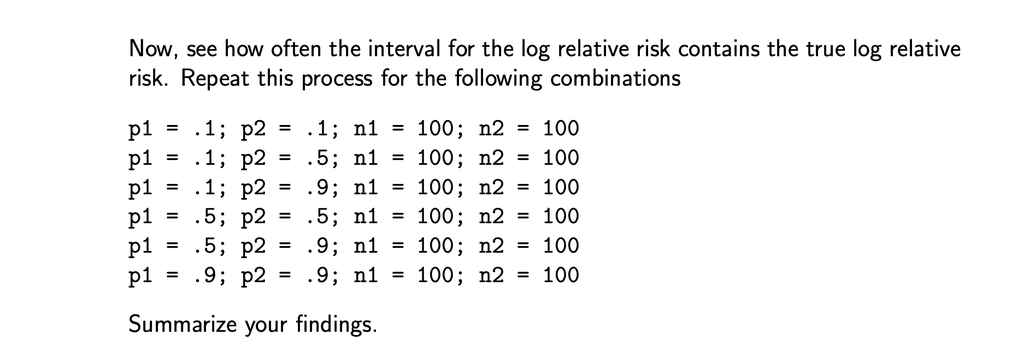

```r
# Function to calculate the proportion of time the CI for the log relative risk (LRR)
# contains the true log relative risk
# Input:
# p1 success probability for first binomial sample
# p2 success probability for the second binomial sample
# n1 size of first binomial sample
# n2 size of second binomial sample
# Output:
# prop proportion of CI that contain the true log relative risk
logrr_prop <- function(p1, p2, n1, n2){

  # Calculate true LRR
  trueLRR <- log(p1/p2)

  # Simulate random binomials, merge two binomials into matrix z
  x <- rbinom(1000, size = n1, prob = p1)
  y <- rbinom(1000, size = n2, prob = p2)
  ## This matrix has two columns cosisting of x and y vector, respectively
  z <- cbind(x, y)

  # Get 1000 sample RR and log sample RR
  RR <- apply(z, 1, function(x) (x[1] / n1) / (x[2] / n2))
  LRR <- log(RR)

  # Get standard errors for log RRs
  SELOGRR <- apply(z, 1, function(x) {
    phat1 <- x[1] / n1
    phat2 <- x[2] / n2
    sqrt((1 - phat1) / phat1 / n1 + (1 - phat2) / phat2 / n2)}
  )

  # Create CI
  CI_lower <- LRR - 1.96*SELOGRR
  CI_upper <- LRR + 1.96*SELOGRR

  # Calculate proportion of times the true LRR is contained within the CI
  prop <- mean(CI_lower <= trueLRR & CI_upper >= trueLRR)

  return(prop)
}
```

Execute the function above

```r
# Create matrix of parameters
p1 <- c(0.1, 0.1, 0.1, 0.5, 0.5, 0.9)
p2 <- c(0.1, 0.5, 0.9, 0.5, 0.9, 0.9)
n1 <- rep(100, 6)
n2 <- rep(100, 6)
param <- cbind(p1, p2, n1, n2)
param
```

```
##       p1  p2  n1  n2
## [1,] 0.1 0.1 100 100
## [2,] 0.1 0.5 100 100
## [3,] 0.1 0.9 100 100
## [4,] 0.5 0.5 100 100
## [5,] 0.5 0.9 100 100
## [6,] 0.9 0.9 100 100
```

```r
# Get proportion of times the true LRR is contained within the CI using apply
set.seed(12345)
apply(param, 1, function(x) logrr_prop(x[1], x[2], x[3], x[4]))
```

```
## [1] 0.965 0.967 0.952 0.959 0.954 0.956
```

Comment:

- We see that our 95% confidence interval for the log relative risk contains the true relative risk approximately 95% of the time, as expected.

### HW6 Problem 11

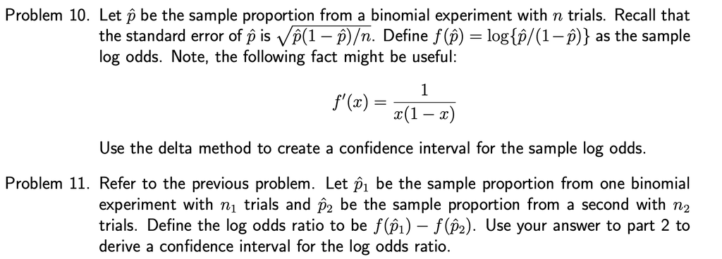

In Problem 10, $f(\hat{p})$ is defined as

$$\begin{aligned}
f(\hat{p})=\log \left( \frac{\hat{p}}{1-\hat{p}} \right)
\end{aligned}$$

and we showed that

$$\begin{aligned}
\sqrt{n}(f(\hat{p})-f(p)) \stackrel{D}{\rightarrow} N\left(0, \frac{1}{p(1-p)}\right) \\
(f(\hat{p})-f(p)) \stackrel{D}{\rightarrow} N\left(0, \frac{1}{np(1-p)}\right) \\
\log \left(\frac{\hat{p}}{1-\hat{p}}\right)-\log \left(\frac{p}{1-p}\right) \stackrel{D}{\rightarrow} N\left(0, \frac{1}{n p(1-p)}\right).
\end{aligned}$$

We use the above to state that

$$\begin{aligned}
\log\left(\frac{\hat{p}_1}{1-\hat{p}_1}\right) - \log\left(\frac{p_1}{1-p_1}\right) &\xrightarrow{D} N\left(0, \frac{1}{n_1p_1(1-p_1)} \right)\\
\log\left(\frac{\hat{p}_2}{1-\hat{p}_2}\right) - \log\left(\frac{p_2}{1-p_2}\right) &\xrightarrow{D} N\left(0, \frac{1}{n_2p_2(1-p_2)} \right)
\end{aligned}$$

Thus, assuming independence of the 2 experiments, we have

$$\begin{aligned}
\log\left( \frac{\hat{p}_1/(1-\hat{p}_1)}{\hat{p}_2/(1-\hat{p}_2)}\right) - \log \left( \frac{p_1/(1-p_1)}{p_2(1-p_2)}\right)\xrightarrow{D} N\left(0, \frac{1}{n_1p_1(1-p_1)} + \frac{1}{n_2p_2(1-p_2)}\right)
\end{aligned}$$

Using the sample proportions to estimate the true proportions, the $(1-\alpha) \%$ confidence interval for the sample log-odds ratio is given by,

$$\log\left( \frac{\hat{p}_1}{1-\hat{p}_1}\right) - \log\left( \frac{\hat{p}_2}{1-\hat{p}_2}\right) \pm z_{1-\alpha/2}\sqrt{\frac{1}{n_1p_1(1-p_1)} + \frac{1}{n_2p_2(1-p_2)}}$$

Or equivalently,

$$\log\left( \frac{\hat{p}_1}{1-\hat{p}_1}\right) - \log\left( \frac{\hat{p}_2}{1-\hat{p}_2}\right) \pm z_{1-\alpha/2}\sqrt{\frac{1}{n_1p_1} + \frac{1}{n_1(1-p_1)} + \frac{1}{n_2p_2} + \frac{1}{n_2(1-p_2)}}$$